# ‘AeRobiology’ R package

# 13 Function iplot_pheno()

The function **iplot_pheno()** generates a boxplot based on phenological parameters (start_dates and end_dates) which are calculated by the estimation of the main parameters of the pollen season. The main arguments are:

- **data**: A `data.frame` object including the general database where calculation of the pollen season must be applied in order to generate the phenological plot based on the start_dates and end_dates. This data.frame must include a first column in “Date” format and the rest of columns in “numeric” format belonging to each pollen type by column.
- **method**: A `character` string specifying the method applied to calculate the pollen season and the main parameters. The implemented methods that can be used are: “percentage”, “logistic”, “moving”, “clinical” or “grains”. A more detailed information about the different methods for defining the pollen season may be consulted in calculate_ps function.
- **n.types**: A `numeric` (integer) value specifying the number of the most abundant pollen types that must be represented. A more detailed information about the selection of the considered pollen types may be consulted [here](https://cran.r-project.org/web/packages/AeRobiology/AeRobiology.pdf). The `n.types` argument will be 15 by default.
- **type.plot**: A `character` string specifying the type of plot selected to show the phenological plot. The implemented types that may be used are: “static” (generates a static ggplot object) and “dynamic” (generates a dynamic plotly object).
- Other arguments related to **calculate_ps() function**

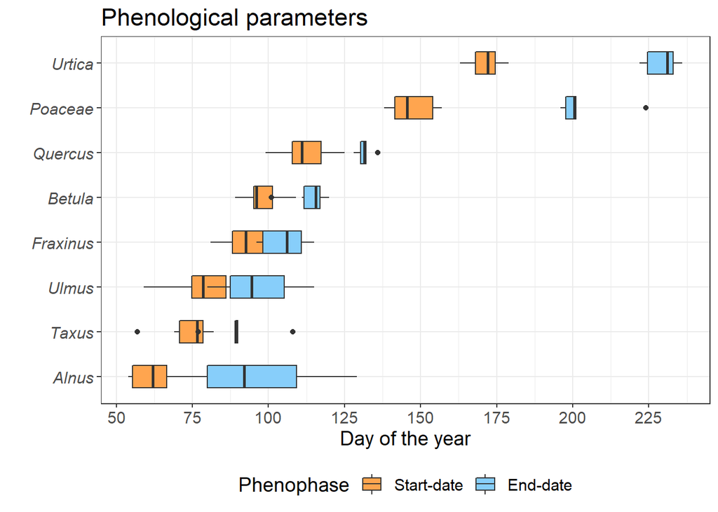

```r
iplot_pheno(munich, method= "percentage", perc=80, int.method="spline", n.types = 8)
```

We can change the method to establish the main pollen season and the number of pollen types to show:

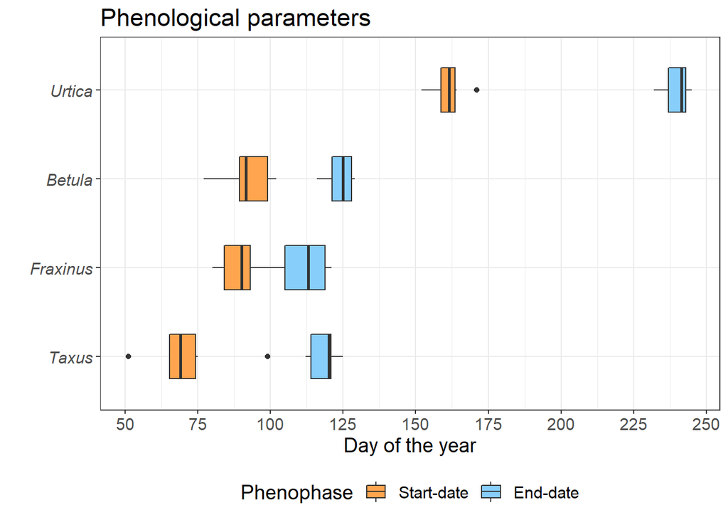

```r
iplot_pheno(munich, method= "clinical", n.clinical = 3, int.method="spline", n.types = 4)
```

Furthermore, we can make the plot interactive to obtain more information by clicking in each object:

```r
iplot_pheno(munich, method= "clinical", n.clinical = 3, int.method="spline", n.types = 4, type.plot = "dynamic")
```

# 14 Function ps_plot()

The function **ps_plot() function** was designed to plot the main pollen season of a single pollen type and year. Some of the arguments are:

- **data**: A `data.frame` object including the general database where interpollation must be performed. This data.frame must include a first column in “Date” format and the rest of the columns in “numeric” format. Each column must contain information of one pollen type. It is not necessary to insert missing gaps, the function will automatically detect them.
- **pollen.type**: A `character` string specifying the name of the pollen type which will be plotted. The name must be exactly the same that appears in the column name. Mandatory argument with no default.
- **year**: A `numeric` (interger) value specifying the season to be plotted. The season does not necessary fit a natural year. See calculate_ps for more details. Mandatory argument with no default.
- **export.plot**: A `logical` argument. If `TRUE`, the graph created will be exported in a new folder (“plot_AeRobiology”) in your working directory. The `export.plot` argument will be `TRUE` by default.
- **days**: A `numeric` (interger) specifying the number of days beyond each side of the main pollen season that will be represented. The `days` argument will be 30 by default.
- **fill.col**: A `character` string specifying the name of the color to fill the main pollen season in the plot. See ggplot function for more details. The `fill.col` argument will be “turquoise4” by default. It uses the ggplot color codes.
- **axisname**:A `character` string specifying the title of the y axis. By default, `axisname = expression(paste("Pollen grains / m"^"3"))`
- Others…

**calculate_ps function** is integrated in this function. Consult [here](https://cran.r-project.org/web/packages/AeRobiology/AeRobiology.pdf) for more information. **Interpolation is mandatory** for this function. Due to technical encoding, you must use interpollen function through calculate_ps function. Consult calculate_ps for more information.

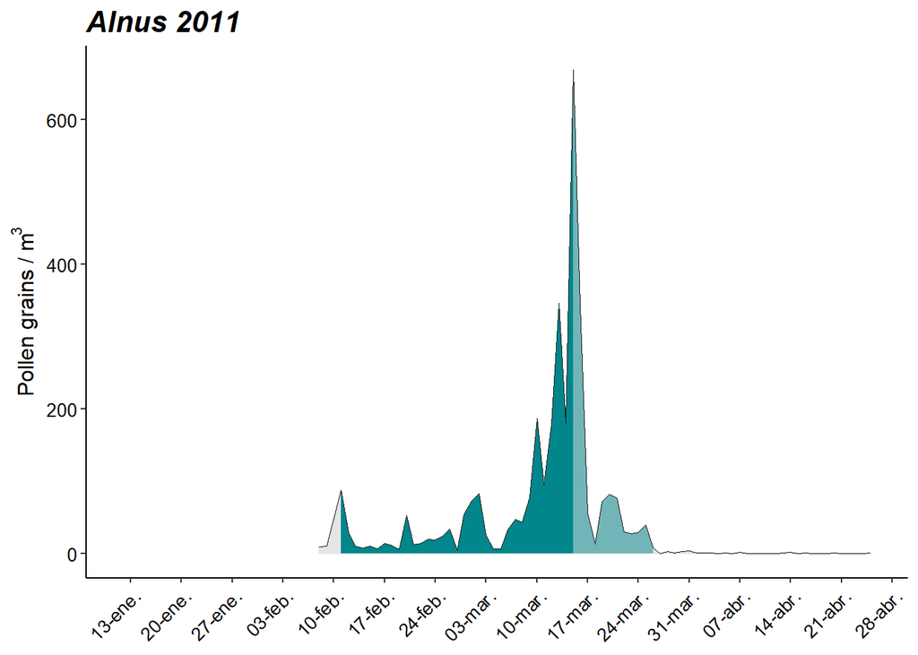

```r
ps_plot(munich, pollen.type="Alnus", year=2011)
```

If you misspell some pollen type name, the function will tell you:

```r
ps_plot(munich, pollen.type="Alnuscdscscr", year=2011)
```

```
## Error in ps_plot(munich, pollen.type = "Alnuscdscscr", year = 2011): pollen.type: Please, insert only a pollen type which is in your database (type the exact name)
```

**Let`s test more arguments:**

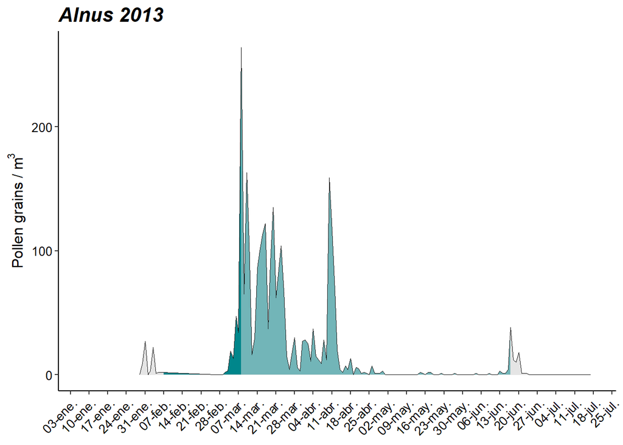

```r
ps_plot(munich, pollen.type="Alnus", year=2013, method= "percentage", perc=95 ,int.method = "lineal")
```

As you have noticed, the arguments `method`, `perc` and `int.method` are from **calculate_ps function**.

What about changing the interpolation method?

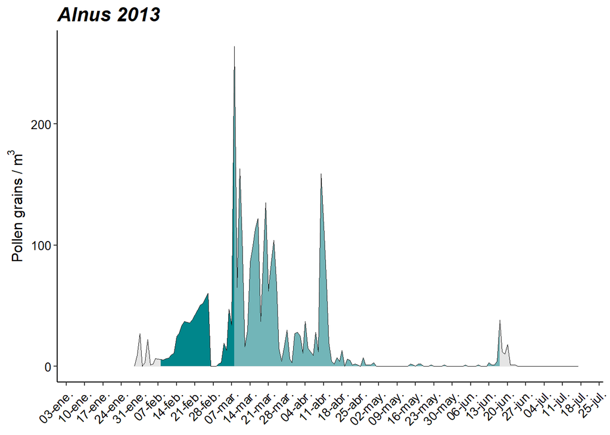

```r
ps_plot(munich, pollen.type="Alnus", year=2013, method= "percentage", perc=95 ,int.method = "movingmean")
```

Do you want a larger scale?

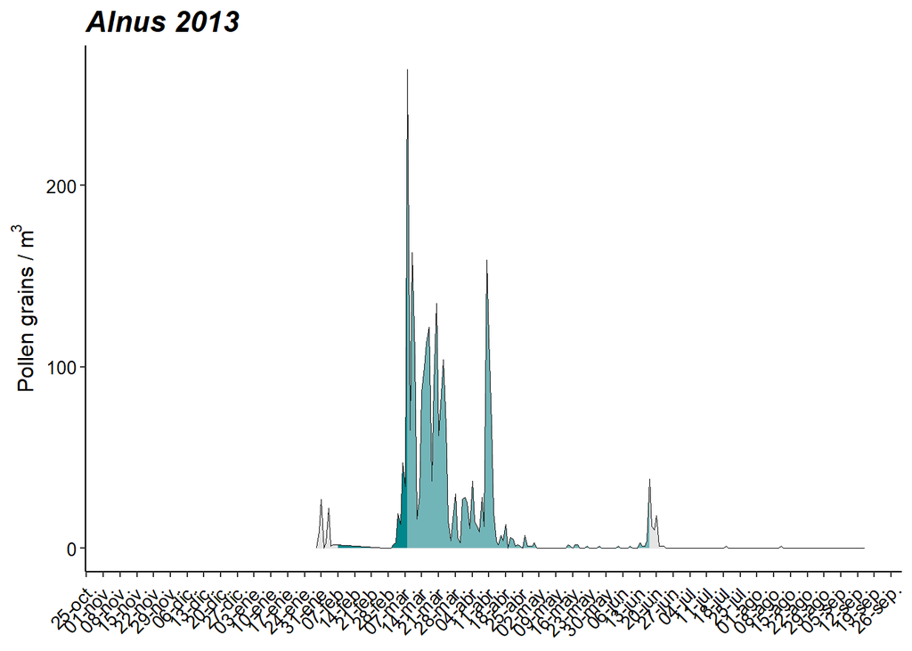

```r
ps_plot(munich, pollen.type="Alnus", year=2013, days = 90)
```

Maybe a different color and y-axis name?

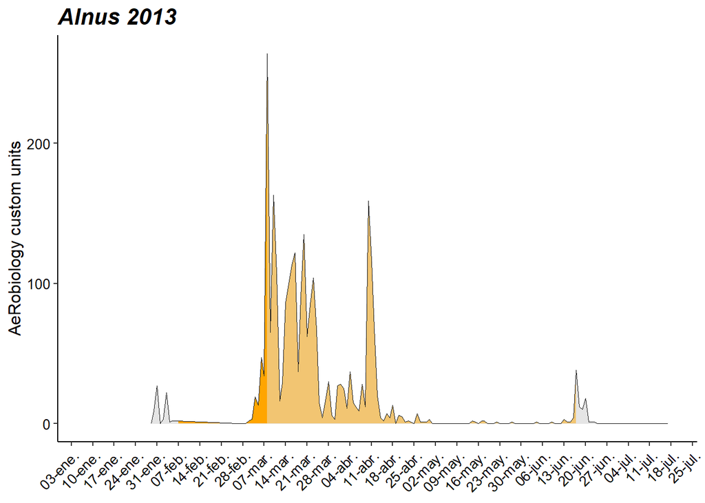

```r
ps_plot(munich, pollen.type="Alnus", year=2013, fill.col = "orange", axisname = "AeRobiology custom units")
```

[^1]: University of Castilla-La Mancha & ZAUM
[^2]: University of Malaga
[^3]: Zentrum Allergie und Umwelt (ZAUM)